# Hierarchial Clustering French Cities

See http://www.r-bloggers.com/clustering-french-cities-based-on-temperatures/?utm_source=feedburner&utm_medium=email&utm_campaign=Feed%3A+RBloggers+%28R+bloggers%29

In order to illustrate hierarchical clustering techniques and k-means, I did borrow François Husson‘s dataset, with monthly average temperature in several French cities.

```r
temp=read.table("http://freakonometrics.free.fr/FR_temp.txt", header=TRUE,dec=",")
```

We have 15 cities, with monthly observations

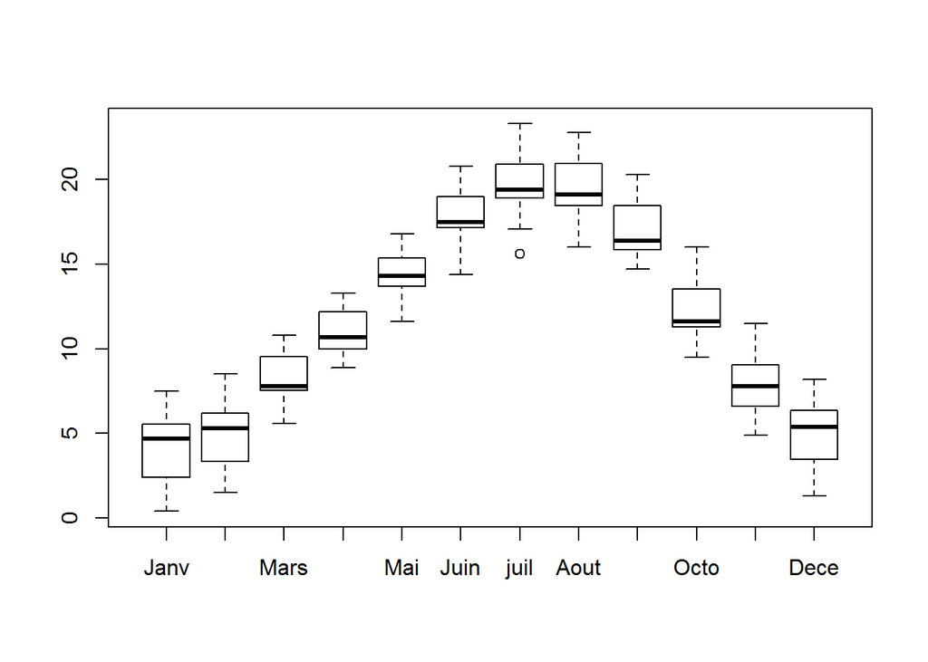

```r
X=temp[,1:12]
boxplot(X)
```

Since the variance seems to be rather stable, we will not ‘normalize’ the variables here,

```r
apply(X,2,sd)
```

```
##     Janv     Fevr     Mars     Avri      Mai     Juin     juil     Aout
## 2.007296 1.868409 1.529083 1.414820 1.504596 1.793507 2.128939 2.011988
##     Sept     Octo     Nove     Dece
## 1.848114 1.829988 1.803753 1.958449
```

In order to get a hierarchical cluster analysis, use for instance

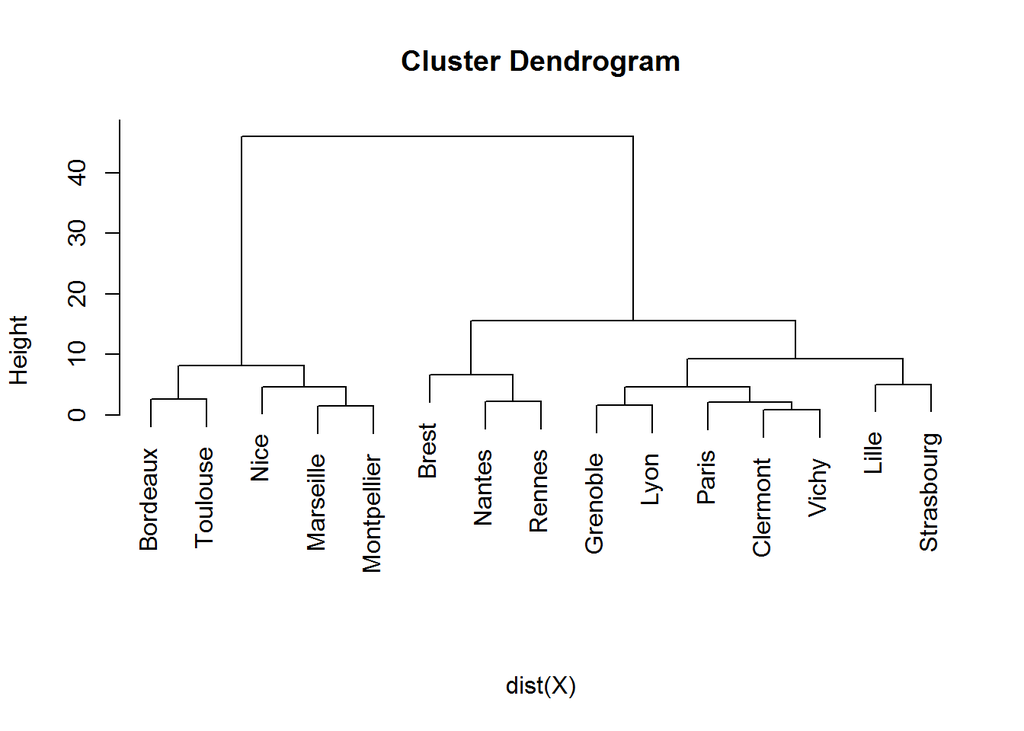

```r
h <- hclust(dist(X), method = "ward")
plot(h, labels = rownames(X), sub = "")
```

An alternative is to use

```r
library(FactoMineR)
```

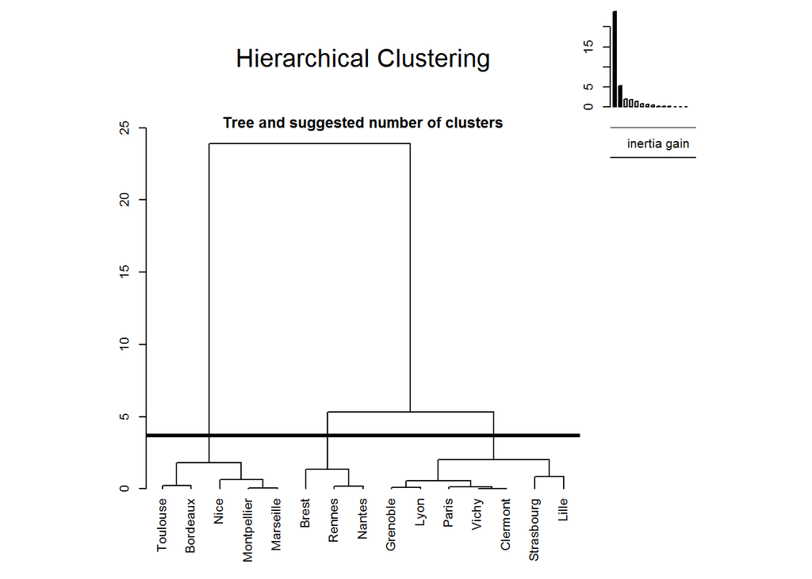

```r
h2=HCPC(X)
```

```r
dev.off() #needed to add this to avoid "Error in plot.new() : figure margins too large"
```

```r
plot(h2)
```

[output not shown]

Here, we visualise observations with a principal components analysis. We have here also an automatic selection of the number of classes, here 3. We can get the description of the groups using

```r
h2$desc.ind
```

```
## $para
## Cluster: 1
##     Vichy  Clermont  Grenoble     Paris      Lyon
## 0.7236529 1.1841642 2.0800314 2.3900303 2.9402554
## --------------------------------------------------------
## Cluster: 2
##   Rennes   Nantes    Brest
## 1.217009 2.758824 3.646155
## --------------------------------------------------------
## Cluster: 3
## Montpellier    Bordeaux   Marseille    Toulouse        Nice
##    0.860465    2.135041    2.175868    3.878969    4.018507
##
## $dist
## Cluster: 1
## Strasbourg       Lyon   Grenoble      Lille      Vichy
##   9.565273   7.548804   7.463764   5.959400   5.599504
## --------------------------------------------------------
## Cluster: 2
##    Brest   Nantes   Rennes
## 9.174388 5.161889 5.019757
## --------------------------------------------------------
## Cluster: 3
##        Nice   Marseille Montpellier    Bordeaux    Toulouse
##   13.081964   12.176252   10.778889    8.469619    7.016726
```

or directly

```r
cah=hclust(dist(X))
groups.3 <- cutree(cah,3)
```

We can also visualise those classes by ourselves,

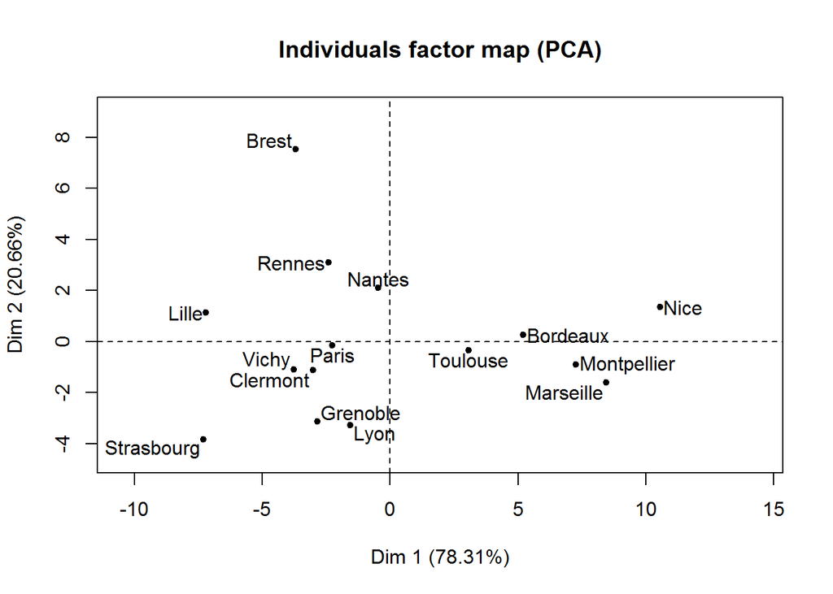

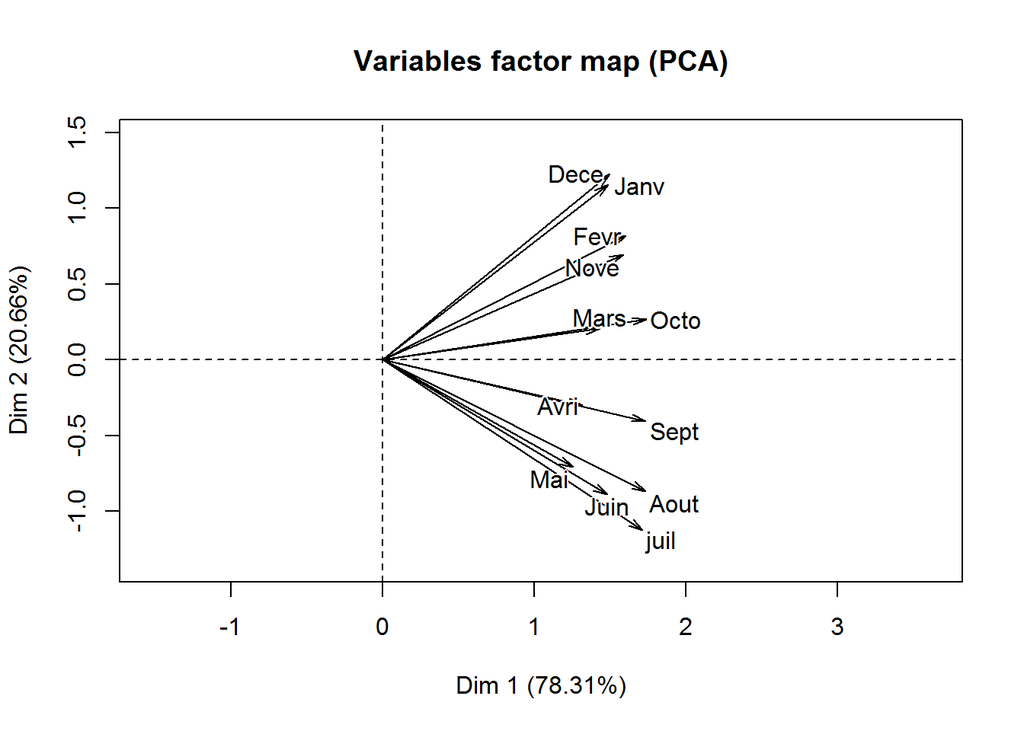

```r
acp=PCA(X,scale.unit=FALSE)
```

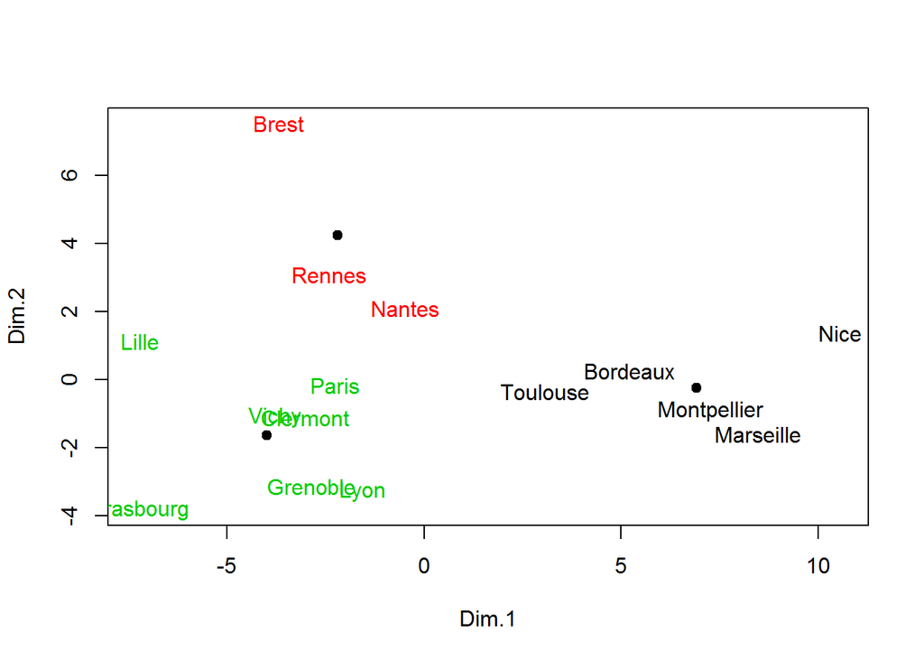

```r
plot(acp$ind$coord[,1:2],col="white")
text(acp$ind$coord[,1],acp$ind$coord[,2], rownames(acp$ind$coord),col=groups.3)

#It is possible to plot the centroïds of those clusters

PT=aggregate(acp$ind$coord,list(groups.3),mean)
points(PT$Dim.1,PT$Dim.2,pch=19)
```

If we add Voroid sets around those centroïds, here we do not see them (actually, we see the point – in the middle – that is exactly at the intersection of the three regions),

```r
library(tripack)
```

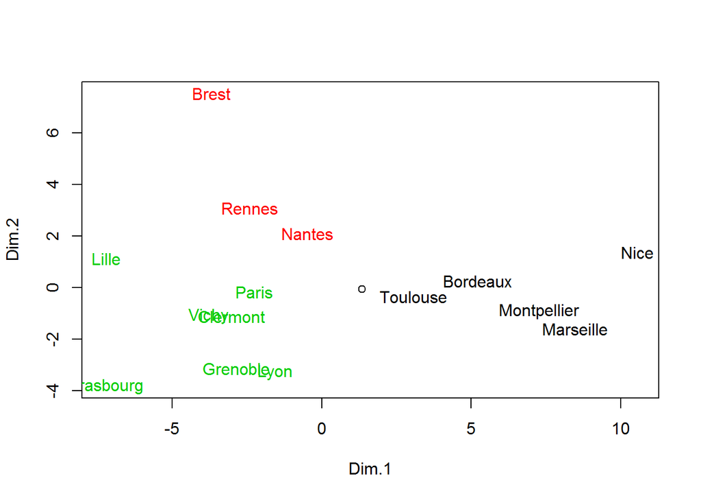

```r
plot(acp$ind$coord[,1:2],col="white")
text(acp$ind$coord[,1],acp$ind$coord[,2], rownames(acp$ind$coord),col=groups.3)
V <- voronoi.mosaic(PT$Dim.1,PT$Dim.2)
plot(V,add=TRUE)
```

To visualize those regions, use

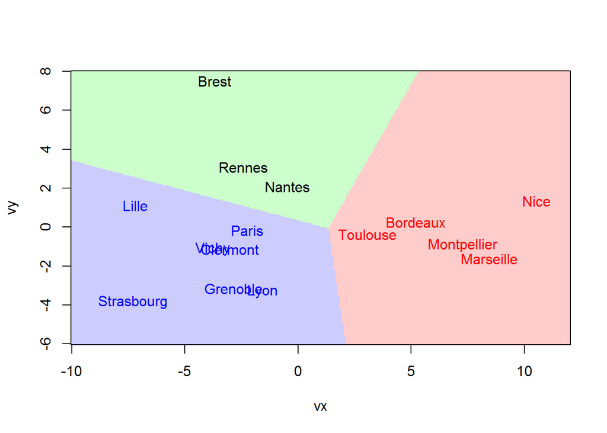

```r
p=function(x,y){which.min((PT$Dim.1-x)^2+(PT$Dim.2-y)^2)}

vx=seq(-10,12,length=251)
vy=seq(-6,8,length=251)
z=outer(vx,vy,Vectorize(p))
image(vx,vy,z,col=c(rgb(1,0,0,.2), rgb(0,1,0,.2),rgb(0,0,1,.2)))
CL=c("red","black","blue")
text(acp$ind$coord[,1],acp$ind$coord[,2], rownames(acp$ind$coord),col=CL[groups.3])
```

```r
km=kmeans(acp$ind$coord[,1:2],3)
km
```

```
## K-means clustering with 3 clusters of sizes 3, 2, 10
##
## Cluster means:
##       Dim.1       Dim.2
## 1  8.757410 -0.38251998
## 2  4.137651 -0.04243546
## 3 -3.454753  0.12324309
##
## Clustering vector:
##    Bordeaux       Brest    Clermont    Grenoble       Lille        Lyon
##           2           3           3           3           3           3
##   Marseille Montpellier      Nantes        Nice       Paris      Rennes
##           1           1           3           1           3           3
##  Strasbourg    Toulouse       Vichy
##           3           2           3
##
## Within cluster sum of squares by cluster:
## [1]  10.364888   2.472405 153.992864
##  (between_SS / total_SS =  69.7 %)
##
## Available components:
##
## [1] "cluster"      "centers"      "totss"        "withinss"
## [5] "tot.withinss" "betweenss"    "size"         "iter"
## [9] "ifault"
```

But actually, since again we have some spatial data, it is possible to visualize them on a map

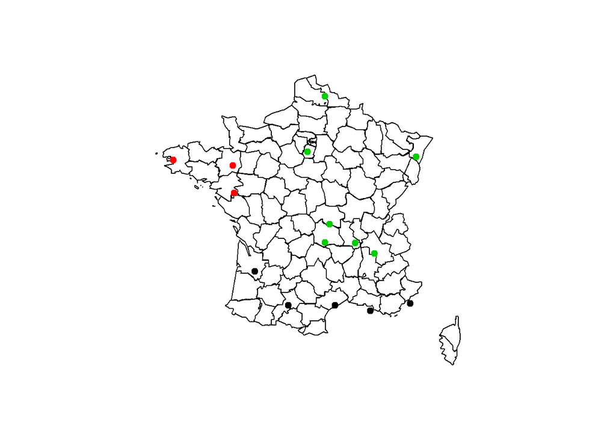

```r
library(maps)
map("france")
points(temp$Long,temp$Lati,col=groups.3,pch=19)
```

or, to visualize the regions, use e.g.

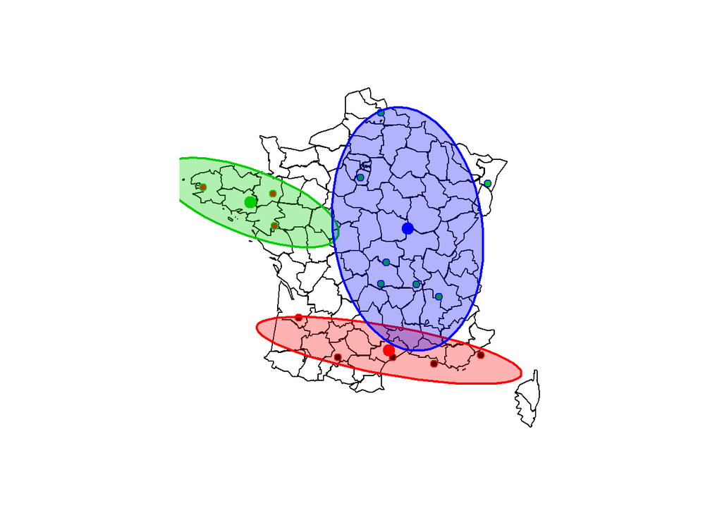

```r
library(car)
map("france")
points(temp$Long,temp$Lati,col=groups.3,pch=19)
for(i in 1:3)
dataEllipse(temp$Long[groups.3==i], temp$Lati[groups.3==i], levels=.7,add=TRUE, col=i+1,fill=TRUE)
```